# Lab 3B

Tree-based methods and SVM’s

2021

In this lab we classify the `spam4` data again, but using different techniques than in the previous lab. For this lab you need the packages `kernlab`, `tree`, `randomForest`, `fastAdaboost`, `e1071` and `caret`.

```r
knitr::opts_chunk$set(eval=params$answers,
                      message=FALSE)
library(kernlab)
library(tree)
library(randomForest)
library(fastAdaboost)
library(caret)
library(e1071)
library(dplyr)
```

# Training the models

To compare our results, we use the same training and test set.

1. Load the `spam` data, and convert it to `spam4` as in the previous lab.

```r
data("spam")
spam4 <- spam %>%
  mutate(across(1:57, ntile, 4))
```

2. Make the same vector with indices for the training set as in the previous lab.

```r
set.seed(10)
train <- createDataPartition(y = spam4$type, p = .75, list = FALSE)
```

## Tree

1. Grow a tree on the training set. Save the object as `train_tree`, and plot it.

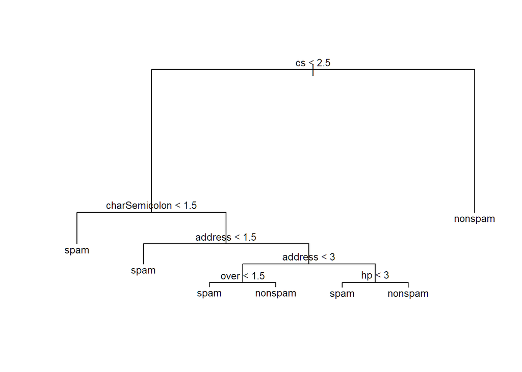

```r
train_tree <- tree(type ~ ., data = spam4[train, ])
plot(train_tree)
text(train_tree, cex = 0.8)
```

2. The fitted may be overfitting. Before we can prune the tree we need to determine the optimal number of knots. Find out this number by performing cross-validation with the function `cv.tree()`.

```r
cv_tree <- cv.tree(train_tree)
cv_tree
```

```
## $size
## [1] 7 6 5 4 3 2 1
##
## $dev
## [1]  257.3475  393.9101  409.8162 1091.1094 1112.5346 1813.2334 4630.0804
##
## $k
## [1]       -Inf   77.80511   90.61083  376.35821  398.41063  627.54422 2841.46530
##
## $method
## [1] "deviance"
##
## attr(,"class")
## [1] "prune"         "tree.sequence"
```

4. Prune the tree using the optimal number of nodes from the cross-validation, and save the pruned tree object under an appropriate name.

```r
prune_tree <- prune.tree(train_tree, best = cv_tree$size[which.min(cv_tree$dev)])
```

## Bagging/random forest

Both models can be trained with the function `randomForest()`. The only argument that needs to be changed is `mtry` (see the function’s help page). To learn about the importance of the features, set the argument `importance = TRUE`.

1. Train the bagging model, save its object as `train_bag`, and display and interpret its content.

```r
(train_bag <- randomForest(type ~ ., spam4[train, ], importance = TRUE, mtry = 57))
```

```
##
## Call:
##  randomForest(formula = type ~ ., data = spam4[train, ], importance = TRUE,      mtry = 57)
##                Type of random forest: classification
##                      Number of trees: 500
## No. of variables tried at each split: 57
##
##         OOB estimate of  error rate: 0.26%
## Confusion matrix:
##         nonspam spam class.error
## nonspam    2087    4 0.001912960
## spam          5 1355 0.003676471
```

2. Train the random forest model, save its object as `train_rf`, display its content and compare it to that of the random forest object.

```r
(train_rf  <- randomForest(type ~ ., spam4[train, ], importance = TRUE))
```

```
##
## Call:
##  randomForest(formula = type ~ ., data = spam4[train, ], importance = TRUE)
##                Type of random forest: classification
##                      Number of trees: 500
## No. of variables tried at each split: 7
##
##         OOB estimate of  error rate: 0.06%
## Confusion matrix:
##         nonspam spam  class.error
## nonspam    2090    1 0.0004782401
## spam          1 1359 0.0007352941
```

3. Display the variable importance plots of both objects for the 10 most important predictors, and interpret.

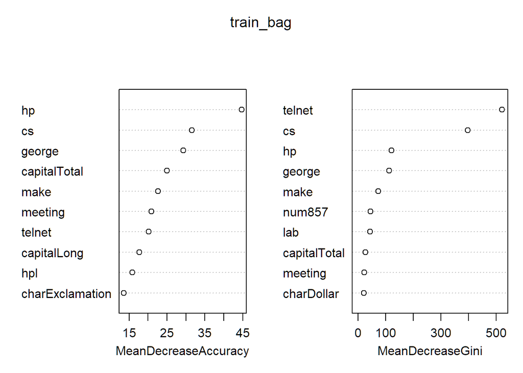

```r
varImpPlot(train_bag, n.var = 10)
```

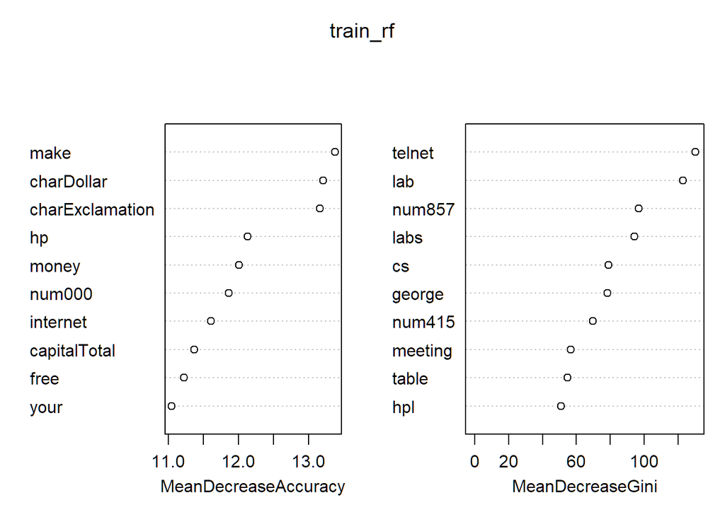

```r
varImpPlot(train_rf, n.var = 10)
```

## Boosting

For boosting we use the `train()` function with the “adaboost” method for tuning the `nIter` hyperparameter (see lecture slides).

1. Run the code on the slides, and provide a sequence of numbers for tuning `nIter`. Save the `train` object under an appropriate name.

```r
train_boost <- train(type ~ .,
                     data       = spam4[train, ],
                     method     = "adaboost",
                     tuneGrid   = expand.grid(method = "Adaboost.M1", nIter = c(10, 25, 50)),
                     trControl  = trainControl(method = "cv",
                                               number = 5)
)
```

2. Display and interpret the fitted object.

```r
train_boost
```

```
## AdaBoost Classification Trees
##
## 3451 samples
##   57 predictor
##    2 classes: 'nonspam', 'spam'
##
## No pre-processing
## Resampling: Cross-Validated (5 fold)
## Summary of sample sizes: 2761, 2761, 2761, 2760, 2761
## Resampling results across tuning parameters:
##
##   nIter  Accuracy   Kappa
##   10     0.9979710  0.9957569
##   25     0.9988406  0.9975725
##   50     0.9988406  0.9975725
##
## Tuning parameter 'method' was held constant at a value of Adaboost.M1
## Accuracy was used to select the optimal model using the largest value.
## The final values used for the model were nIter = 25 and method = Adaboost.M1.
```

## Support Vector Machines

1. The `svm()` function offers four different kernels and has many hyperparameters that can be tuned. To restrict the choices, use the function `tune("svm", . . .)` to tune the `cost` parameter for an svm with a radial kernel. The default value for `cost` is 1, so try out a sequence of values in that neighborhood. Save the `tune` object under an appropriate name.

```r
train_svm  <- tune("svm", type ~ .,
                     data        = spam4[train, ],
                     kernel      = "radial",
                     probability = TRUE,
                     ranges      = list(cost = c(1:4)))

summary(train_svm)
```

```
##
## Parameter tuning of 'svm':
##
## - sampling method: 10-fold cross validation
##
## - best parameters:
##  cost
##     4
##
## - best performance: 0.004345313
##
## - Detailed performance results:
##   cost       error  dispersion
## 1    1 0.005214878 0.002282169
## 2    2 0.004925023 0.003067161
## 3    3 0.004345313 0.003126922
## 4    4 0.004345313 0.002812583
```

2. Display the best model in the `tune` object.

```r
train_svm$best.model
```

```
##
## Call:
## best.tune(method = "svm", train.x = type ~ ., data = spam4[train,
##     ], ranges = list(cost = c(1:4)), kernel = "radial", probability = TRUE)
##
##
## Parameters:
##    SVM-Type:  C-classification
##  SVM-Kernel:  radial
##        cost:  4
##
## Number of Support Vectors:  190
```

3. Display a classification plot for two features of your own choice, and interpret.

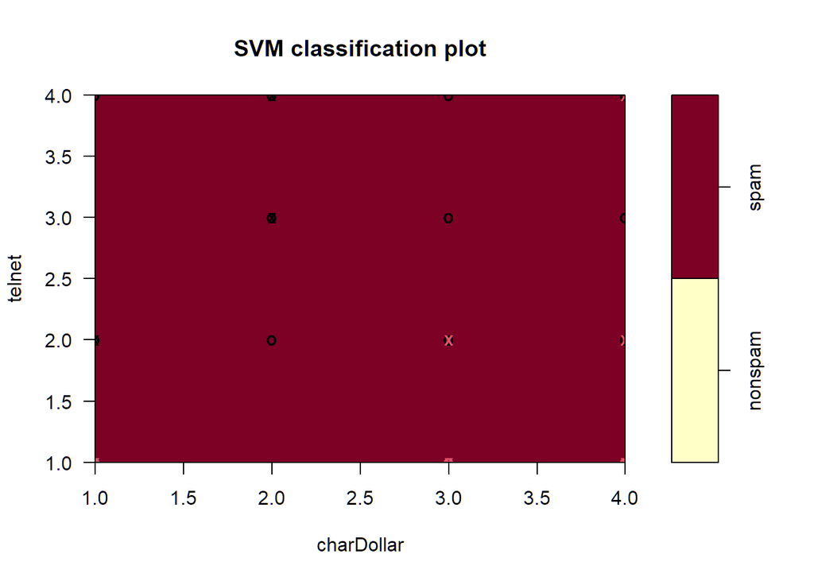

```r
plot(train_svm$best.model, spam4, telnet ~ charDollar)
```

# Testing the models

As in the previous labs, evaluate the five models (pruned tree, bagging, random forest, boosting and svm) by comparing the misclassification test error rates.

1. Save the class predictions of the models on the test set.

```r
class_tree  <- predict(prune_tree,           spam4[-train, ], type = "class")

class_bag   <- predict(train_bag,            spam4[-train, ])

class_rf    <- predict(train_rf,             spam4[-train, ])

class_boost <- predict(train_boost,          spam4[-train, ])

class_svm   <- predict(train_svm$best.model, spam4[-train, ])
```

2. Obtain and display the confusion matrices.

```r
cf <- function(obs = spam4[-train, 58], est)table(obs = obs, est = est)

(conf_tree <- cf(est = class_tree))
```

```
##          est
## obs       nonspam spam
##   nonspam     690    7
##   spam          3  450
```

```r
(conf_bag <- cf(est = class_bag))
```

```
##          est
## obs       nonspam spam
##   nonspam     696    1
##   spam          1  452
```

```r
(conf_rf <- cf(est = class_rf))
```

```
##          est
## obs       nonspam spam
##   nonspam     696    1
##   spam          1  452
```

```r
(conf_boost <- cf(est = class_boost))
```

```
##          est
## obs       nonspam spam
##   nonspam     696    1
##   spam          0  453
```

```r
(conf_svm <- cf(est = class_svm))
```

```
##          est
## obs       nonspam spam
##   nonspam     696    1
##   spam          0  453
```

3. Compute, display and compare the misclassification test errors for the five models.

```r
miscl <- function(x) 1 - sum(diag(x)) / sum(x)

data.frame(tree  = miscl(conf_tree),
           bag   = miscl(conf_bag),
           rf    = miscl(conf_rf),
           boost = miscl(conf_boost),
           svm   = miscl(conf_svm)) %>%
  round(4)
```

```
##     tree    bag     rf boost   svm
## 1 0.0087 0.0017 0.0017 9e-04 9e-04
```

4. Compare these test errors to those of the models in the previous lab. What do you conclude?

END OF LAB